# Figures

## 3 Tables

### Table 1

I thought about doing a table that provides summary information and gives a rapid overview of the dataset.

```r
# based on
# https://themockup.blog/posts/2020-10-31-embedding-custom-features-in-gt-tables/
gt_ggplot_driftrate <- function(table_data, plot_col, data_col, plot_fun, ...) {
  # save the data extract ahead of time
  # to be used in our anonymous function below
  data_in <- purrr::pluck(table_data, "_data", data_col)

  # retrieve min max
  range_x <- rbindlist(data_in)[, range(day_departure)]
  range_y <- c(-0.35, 0.15)

  # draw plot
  text_transform(
    table_data,
    # note the use of {{}} here - this is tidy eval
    # that allows you to indicate specific columns
    locations = cells_body(columns = c({{ plot_col }})),
    fn = function(x) {
      # build the plot
      plot <- lapply(data_in, function(x) {
        # build the plot
        ggplot(x) +
          # for color https://davidmathlogic.com/colorblind/#%23D81B60-%231E88E5-%23FFC107-%23004D40
          geom_area(
            aes(x = day_departure, y = ifelse(driftrate < 0,
              driftrate, 0
            )),
            fill = "#5D3A9B", alpha = 0.5
          ) +
          # for color https://davidmathlogic.com/colorblind/#%23D81B60-%231E88E5-%23FFC107-%23004D40
          geom_area(
            aes(x = day_departure, y = ifelse(driftrate > 0,
              driftrate, 0
            )),
            fill = "#E66100", alpha = 0.5
          ) +
          geom_segment(
            aes(
              x = 0,
              y = 0,
              xend = max(day_departure) + 10,
              yend = 0
            ),
            size = 7,
            colour = "grey30",
            arrow = arrow(
              type = "closed",
              length = unit(0.2, units = "npc")
            )
          ) +
          coord_cartesian(xlim = range_x, ylim = range_y) +
          theme_void() +
          theme(
            panel.grid = element_blank(),
            panel.border = element_blank(),
          )
      })

      # draw for every row
      lapply(plot, ggplot_image, aspect_ratio = 5, height = 25)
    }
  )
}
gt_ggplot_sparkline <- function(table_data, plot_col, data_col, plot_fun, ...) {
  # save the data extract ahead of time
  # to be used in our anonymous function below
  data_in <- purrr::pluck(table_data, "_data", data_col)

  # colnames
  col_names <- colnames(rbindlist(data_in))

  # interest variable
  var_interest <- setdiff(col_names, "day_departure")

  # retrieve min max
  range_x <- rbindlist(data_in)[, range(day_departure)]
  range_y <- rbindlist(data_in)[, range(get(var_interest))]

  # draw plot
  text_transform(
    table_data,
    # note the use of {{}} here - this is tidy eval
    # that allows you to indicate specific columns
    locations = cells_body(columns = c({{ plot_col }})),
    fn = function(x) {
      # build the plot
      plot <- lapply(data_in, function(x) {
        # build the plot
        ggplot(x, aes(x = day_departure, y = get(var_interest))) +
          geom_path(size = 6, color = "grey60") +
          geom_smooth(
            size = 10,
            linetype = "dashed",
            colour = "black",
            method = "lm",
            se = FALSE,
            na.rm = TRUE
          ) +
          coord_cartesian(xlim = range_x, ylim = range_y) +
          theme_void() +
          theme(
            panel.grid = element_blank(),
            panel.border = element_blank()
          )
      })

      # draw for every row
      lapply(plot, ggplot_image, aspect_ratio = 4, height = 26)
    }
  )
}
```

```r
# summary_table_es <-
data_comp[, travel_distance := distGeo(
  matrix(c(lon, lat), ncol = 2),
  matrix(c(shift(lon), shift(lat)), ncol = 2)
),
by = .id
] %>%
  as_tibble() %>%
  mutate(id_rename = word(.id, 2, sep = "_")) %>%
  group_by(sp_rename, id_rename) %>%
  summarise(
    N = prettyNum(n(),
      big.mark = ",",
      scientific = FALSE
    ),
    nb_days = round(as.numeric(difftime(
      last(date), first(date),
      units = "days"
    )), 1),
    travel_distance = prettyNum(
      sum(travel_distance, na.rm = T) / 1000,
      digits = 1,
      big.mark = ",",
      scientific = FALSE
    ),
    Maxdepth_mean = round(mean(maxdepth), 1),
    Maxdepth_plus_minus = "±",
    Maxdepth_sd = round(sd(maxdepth), 1),
    Dduration_mean = round(mean(dduration) / 60, 1),
    Dduration_plus_minus = "±",
    Dduration_sd = round(sd(maxdepth) / 60, 1),
    .groups = "drop"
  ) %>%
  # replace travel_distance = 0 by NA
  mutate(travel_distance = na_if(travel_distance, "0")) %>%
  # add driftrate from drift dives
  left_join(
    .,
    data_comp %>%
      as_tibble() %>%
      mutate(id_rename = word(.id, 2, sep = "_")) %>%
      group_by(sp_rename, id_rename, day_departure) %>%
      filter(divetype == "2: drift") %>%
      summarise(
        driftrate = as.numeric(quantile(
          driftrate, 0.5,
          na.rm = T
        )),
        .groups = "drop"
      ) %>%
      group_by(sp_rename, id_rename) %>%
      summarise(
        sparkline_driftrate = list(
          data.frame(
            driftrate = driftrate,
            day_departure = day_departure
          )
        ),
        .groups = "drop"
      ),
    by = c("sp_rename", "id_rename")
  ) %>%
  # add quantile 95 of dduration and max_depth
  left_join(
    .,
    data_comp %>%
      as_tibble() %>%
      mutate(id_rename = word(.id, 2, sep = "_")) %>%
      group_by(sp_rename, id_rename, day_departure) %>%
      summarise(
        maxdepth = as.numeric(quantile(maxdepth, 0.95, na.rm = T)),
        dduration = as.numeric(quantile(dduration, 0.95, na.rm = T)),
        .groups = "drop"
      ) %>%
      group_by(sp_rename, id_rename) %>%
      summarise(
        sparkline_qt_dduration = list(
          data.frame(
            dduration = dduration,
            day_departure = day_departure
          )
        ),
        sparkline_qt_maxdepth = list(
          data.frame(
            maxdepth = -maxdepth,
            day_departure = day_departure
          )
        ),
        .groups = "drop"
      ),
    by = c("sp_rename", "id_rename")
  ) %>%
  # add percentage
  left_join(
    .,
    data_comp %>%
      as_tibble() %>%
      mutate(id_rename = word(.id, 2, sep = "_")) %>%
      group_by(sp_rename, id_rename, divetype) %>%
      summarise(
        n = n(),
        .groups = "drop"
      ) %>%
      group_by(sp_rename, id_rename) %>%
      mutate(
        divetype_perc = round(n * 100 / sum(n)),
        divetype,
        .groups = "drop"
      ) %>%
      arrange(divetype) %>%
      group_by(sp_rename, id_rename) %>%
      summarise(divetype_perc = list(divetype_perc), .groups = "drop"),
    by = c("sp_rename", "id_rename")
  ) %>%
  # add wean mass based on Weanling Dive Metada.xlsx
  left_join(
    .,
    data.table(
      id_rename = c(
        "2018070",
        "2018072",
        "2018074",
        "2018080",
        "140059",
        "140060",
        "140062",
        "140063",
        "140068",
        "140069",
        "140072",
        "140073",
        "140075"
      ),
      sp_rename = c(
        rep("Northern elephant seal", 4),
        rep("Southern elephant seal", 9)
      ),
      weanmass = c(132, 138, 119, 142, 118, 112, 85, NA, 125, NA, NA, 102, NA)
    ),
    by = c("sp_rename", "id_rename")
  ) %>%
  # add wean length based on JoffreyMeasurements 2023_02_01.xlsx and
  # metadata_pups20142015.xlsx
  left_join(
    .,
    data.table(
      id_rename = c(
        "2018070",
        "2018072",
        "2018074",
        "2018080",
        "140059",
        "140060",
        "140062",
        "140063",
        "140068",
        "140069",
        "140072",
        "140073",
        "140075"
      ),
      sp_rename = c(
        rep("Northern elephant seal", 4),
        rep("Southern elephant seal", 9)
      ),
      lenmass = c(144, NA, 131, 142, 141, 141, 118, NA, 136, NA, NA, 134, NA)
    ),
    by = c("sp_rename", "id_rename")
  ) %>%
  # reorder column
  relocate(nb_days, N, travel_distance, weanmass, lenmass, divetype_perc,
    .after = id_rename
  ) %>%
  # setup group row
  gt(groupname_col = "sp_rename") %>%
  # spanner (several columns into one column)
  tab_spanner(
    label = "Maximum depth (m)",
    columns = c(
      Maxdepth_mean,
      Maxdepth_plus_minus,
      Maxdepth_sd,
      sparkline_qt_maxdepth
    )
  ) %>%
  tab_spanner(
    label = "Dive duration (min)",
    columns = c(
      Dduration_mean,
      Dduration_plus_minus,
      Dduration_sd,
      sparkline_qt_dduration
    )
  ) %>%
  tab_spanner(
    label = md("Daily median drift rate"),
    columns = c(sparkline_driftrate)
  ) %>%
  tab_spanner(
    label = md("Travel distance"),
    columns = c(travel_distance)
  ) %>%
  tab_spanner(
    label = md("Mass"),
    columns = c(weanmass)
  ) %>%
  tab_spanner(
    label = md("Length"),
    columns = c(lenmass)
  ) %>%
  tab_spanner(
    label = md("Dive type proportions"),
    columns = c(divetype_perc)
  ) %>%
  # plot
  gt_ggplot_sparkline(sparkline_qt_maxdepth, "sparkline_qt_maxdepth") %>%
  gt_ggplot_sparkline(sparkline_qt_dduration, "sparkline_qt_dduration") %>%
  gt_ggplot_driftrate(sparkline_driftrate, "sparkline_driftrate") %>%
  gt_plt_bar_stack_extra(
    divetype_perc,
    width = 65,
    labels = c("Transit", "Active Btt.", "Drift", "Benthic"),
    palette = c("#000000", "#444444", "#888888", "#CCCCCC")
  ) %>%
  # alignement
  cols_align(
    columns = c(N, Maxdepth_sd, Dduration_sd),
    align = "left"
  ) %>%
  cols_align(
    columns = c(N, Maxdepth_mean, Dduration_mean),
    align = "right"
  ) %>%
  cols_align(
    columns = c(travel_distance, weanmass, lenmass, Maxdepth_plus_minus, Dduration_plus_minus),
    align = "center"
  ) %>%
  # format
  fmt_number(
    columns = Maxdepth_mean,
    decimal = 1
  ) %>%
  fmt_number(
    columns = ends_with("_sd"),
    decimal = 1
  ) %>%
  # rename columns
  cols_label(
    N = "# dives",
    id_rename = md("ID"),
    nb_days = "# days",
    travel_distance = "(km)",
    weanmass = "(kg)",
    lenmass = "(cm)",
    Maxdepth_mean = md("Mean"),
    Maxdepth_plus_minus = md("±"),
    Maxdepth_sd = md("SD"),
    sparkline_qt_maxdepth = md("Trend"),
    Dduration_mean = md("Mean"),
    Dduration_plus_minus = md("±"),
    Dduration_sd = md("SD"),
    sparkline_driftrate = md("(m.s<sup>-1</sup>)"),
    sparkline_qt_dduration = md("Trend")
  ) %>%
  # add color square
  text_transform(
    locations = cells_row_groups(),
    fn = function(x) {
      # identify sp
      sp <- unique(x)
      # set colour
      colour <-
        if_else(grepl("Northern", sp), colours[1], colours[2])
      # html to add the color box
      purrr::map(x, ~ html(
        glue(
          "<div><span style='height: 15px;width: 15px;background-color: {colour};display: inline-block;border-radius:5px;float:left;top:13%;left:5%;'</span> <span style='display: inline-block;float:left;line-height:20px;padding: 0px 25px;white-space:nowrap;'>{sp}</span></div>"
        )
      ))
    }
  ) %>%
  # color cols
  gt_highlight_cols(
    columns = c(
      Maxdepth_mean,
      Maxdepth_plus_minus,
      Maxdepth_sd,
      sparkline_qt_maxdepth,
      sparkline_driftrate,
      weanmass,
      N
    ),
    fill = "lightgrey",
    alpha = 0.5
  ) %>%
  # footnote
  tab_footnote(
    footnote = "Recorded",
    locations = cells_column_labels(columns = c(N, nb_days))
  ) %>%
  # color rows
  opt_row_striping() %>%
  # set horizontal padding for plus minus
  tab_style(
    style = "padding-left:0px;padding-right:0px;",
    locations = cells_column_labels(columns = ends_with("plus_minus"))
  ) %>%
  tab_style(
    style = "padding-left:0px;padding-right:0px;",
    locations = cells_body(columns = ends_with("plus_minus"))
  ) %>%
  # set horizontal padding for plus minus
  tab_style(
    style = "padding-top:0px;padding-bottom:0px",
    locations = cells_body(columns = starts_with("sparkline"))
  ) %>%
  # settings
  tab_options(
    # # width table
    table.width = pct(180),
    # table.width = pct(150),
    # padding = vertical space between rows
    data_row.padding = px(3),
    # horizontal scroll
    container.overflow.x = T
  )
```

ID

# days<sup>1</sup>

# dives<sup>1</sup>

Travel distance

Mass

Length

Dive type proportions

Maximum depth (m)

Dive duration (min)

Daily median drift rate

(km)

(kg)

(cm)

**Transit** | **Active Btt.** | **Drift** | **Benthic**

Mean

±

SD

Trend

Mean

±

SD

Trend

(m.s<sup>-1</sup>)

Northern elephant seal

2018070

229.5

22,390

5,948

132

144

305.5

±

180.0

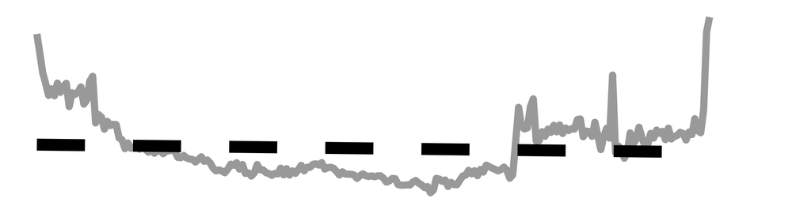

12.9

±

3.0

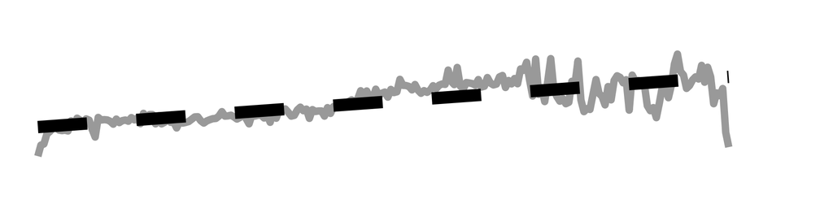

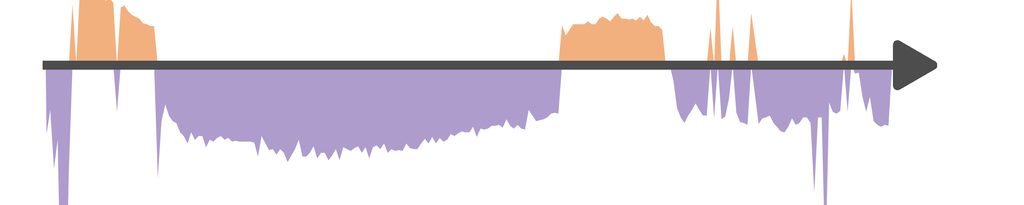

2018072

251.3

22,799

10,430

138

NA

331.6

±

187.2

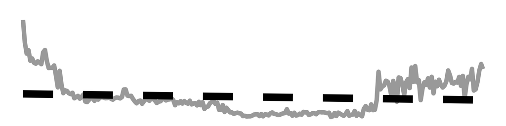

14.1

±

3.1

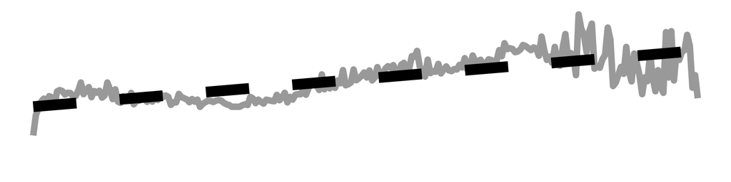

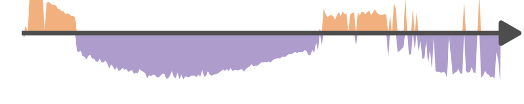

2018074

222.8

25,679

NA

119

131

231.7

±

150.9

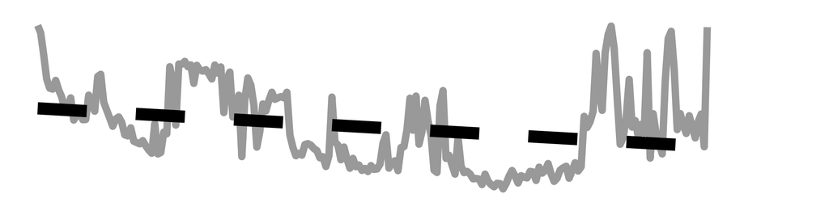

11.1

±

2.5

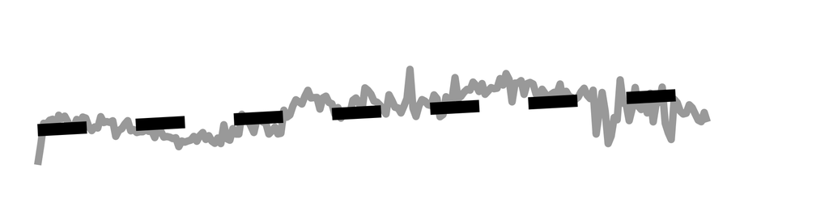

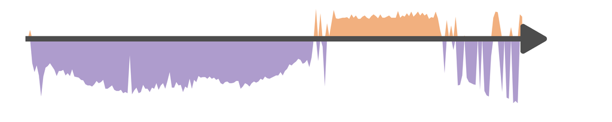

2018080

213.9

19,028

8,334

142

142

296.5

±

146.7

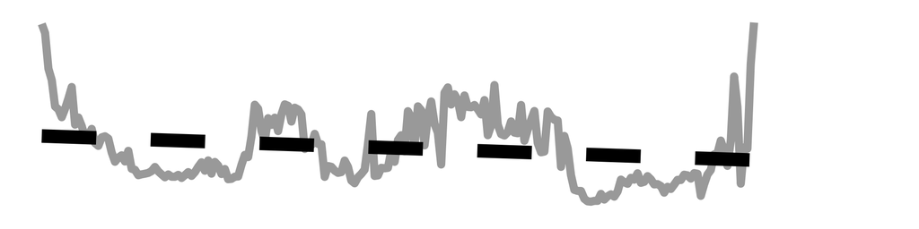

14.5

±

2.4

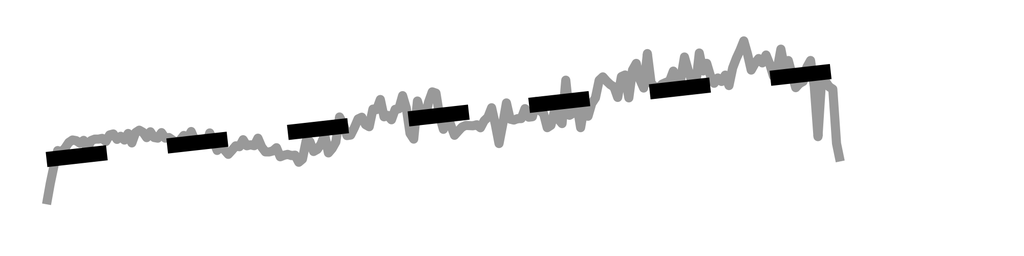

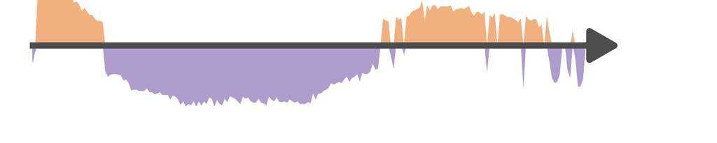

Southern elephant seal

140059

185.3

1,823

7,356

118

141

179.5

±

112.5

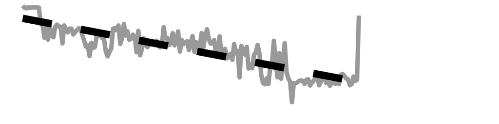

11.4

±

1.9

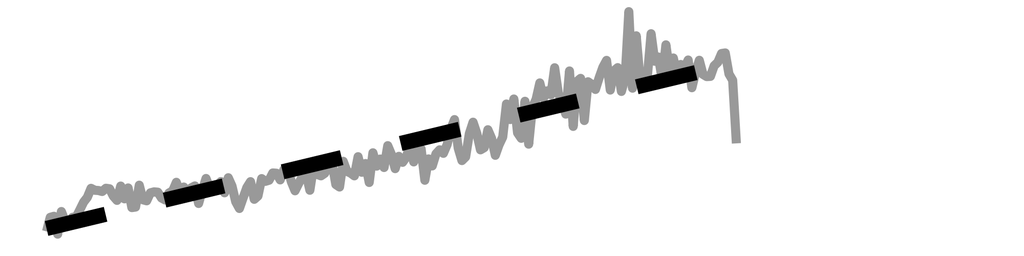

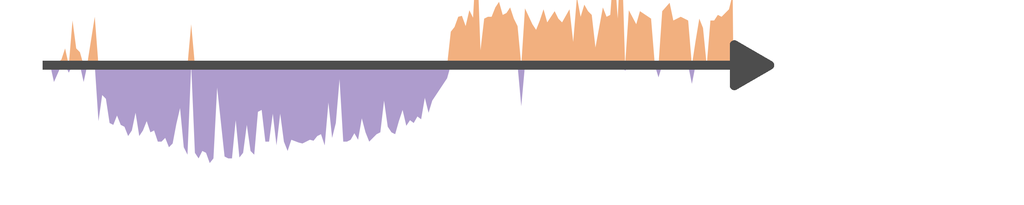

140060

192.4

1,866

8,897

112

141

188.9

±

102.6

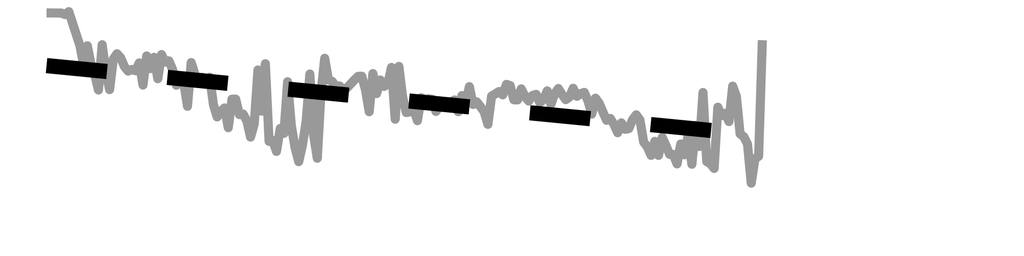

9.7

±

1.7

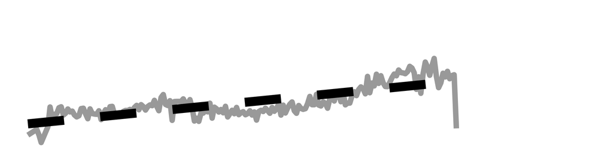

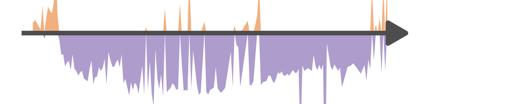

140062

152.3

1,574

5,864

85

118

135.7

±

60.4

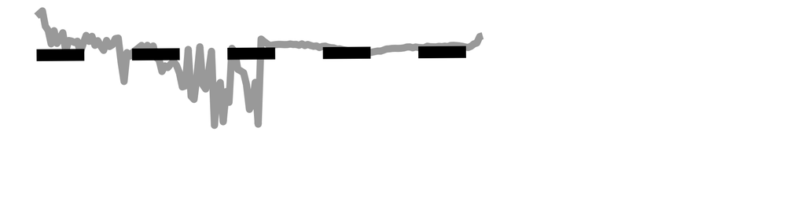

7.0

±

1.0

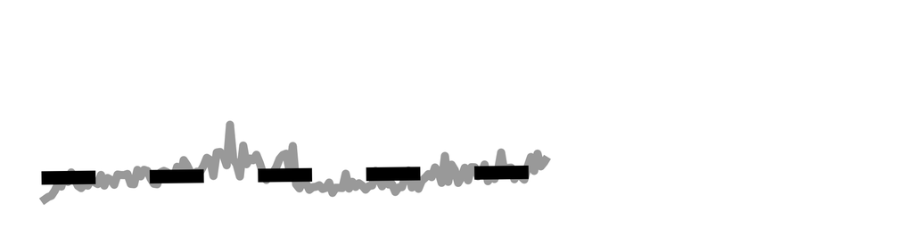

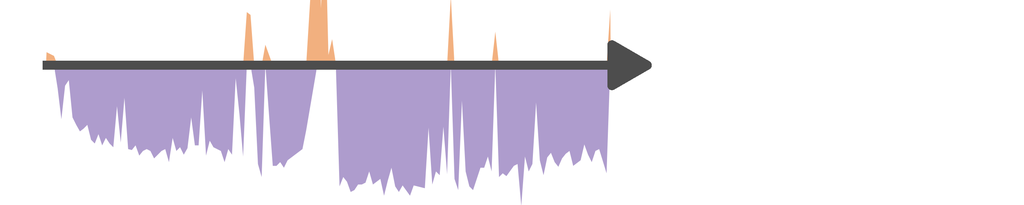

140063

157.5

1,570

7,804

NA

NA

175.1

±

113.0

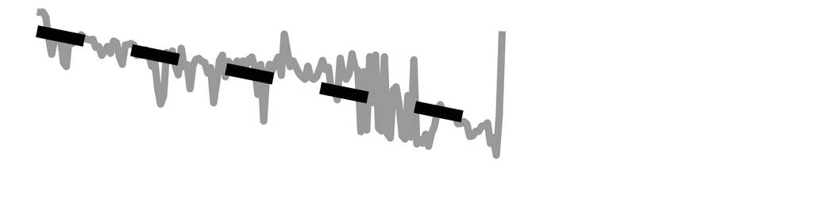

10.2

±

1.9

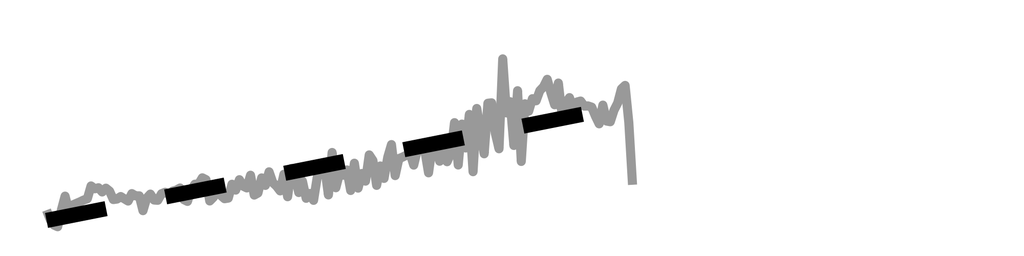

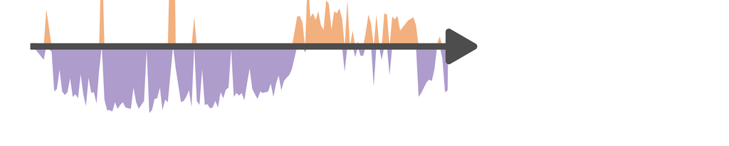

140068

196.9

1,904

8,328

125

136

165.8

±

113.3

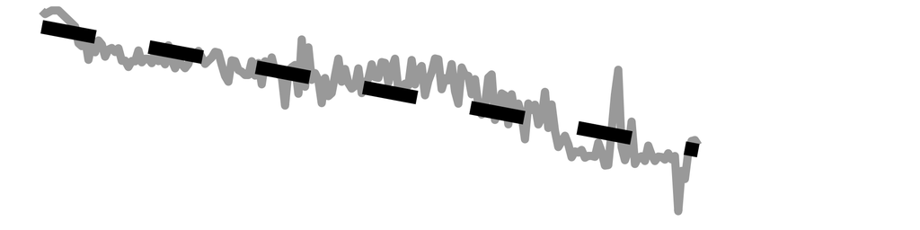

11.1

±

1.9

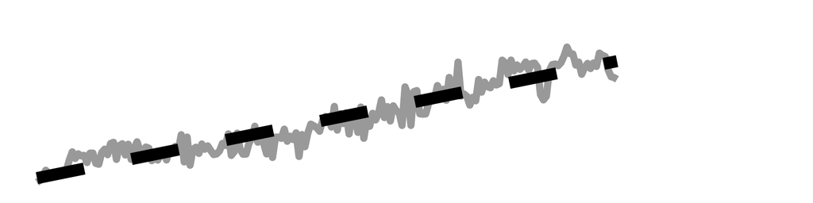

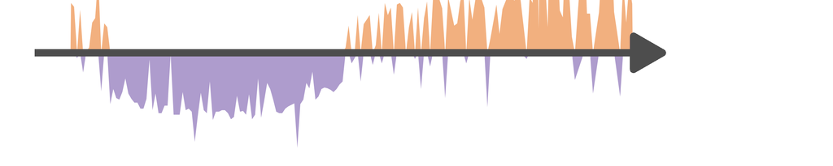

140069

216.3

2,123

8,865

NA

NA

174.0

±

125.1

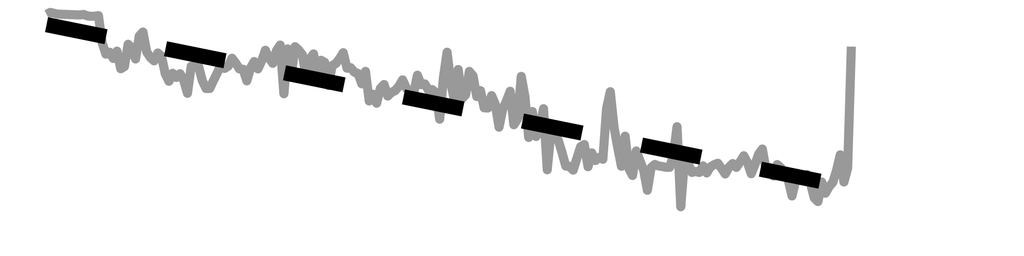

9.2

±

2.1

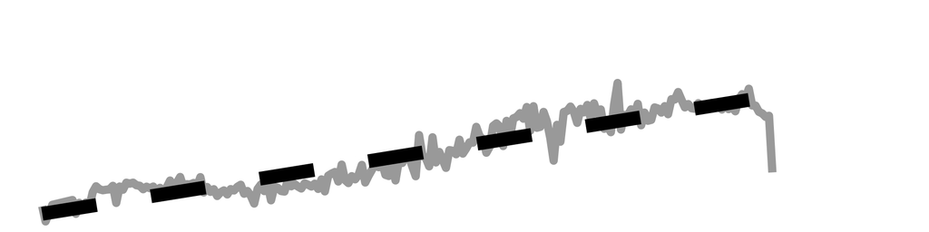

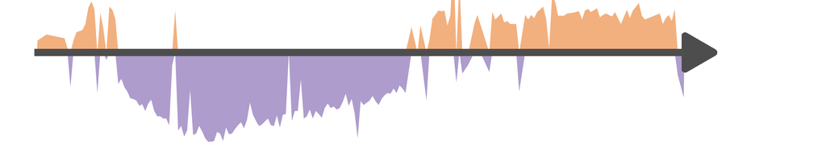

140072